# EXERCICIO 3 - Leticia Trein Medeiros

Leticia Trein Medeiros

2024-06-19

## Objetivo da análise:

A base de dados escolhida foi a **“Melanoma”** do pacote *MASS*, a partir dela, o presente trabalho, busca analisar as variáveis que podem ser mais influentes para levar o paciente a óbito por melanoma. Para isso, será ajustado um modelo de **regressão logística** para prever a probabilidade de óbito causado pelo melanoma.

## Sobre a base de dados:

Para este exercício foi escolhida a base de dados **“Melanoma”** do pacote *MASS*, esta base de dados contém informações sobre **205** pacientes na dinamarca que possuiam melanoma maligno.

Sobre os dados, temos as seguintes variáveis que serão utilizadas no exercício:

A variável **resposta** será *status* e as variáveis **preditoras** serão *sex*, *age*, *thickness* e *ulcer*.

O objetivo é ajustar um modelo de **regressão logística** para prever a probabilidade de óbito causado pelo melanoma.

```r
# Carregar pacotes necessários
library(MASS)
library(dplyr)
```

```r
library(stats)
library(ggplot2)
library(glmtoolbox)
library(knitr)
library(car)
```

### Avaliação inicial do pacote de dados

```r
# Carregar dados
data("Melanoma")
# Visualizar os primeiros registros
head(Melanoma)
```

```
##   time status sex age year thickness ulcer
## 1   10      3   1  76 1972      6.76     1
## 2   30      3   1  56 1968      0.65     0
## 3   35      2   1  41 1977      1.34     0
## 4   99      3   0  71 1968      2.90     0
## 5  185      1   1  52 1965     12.08     1
## 6  204      1   1  28 1971      4.84     1
```

Preparo da base de dados para análise com **seleção e adaptação** das variáveis para uso no modelo de regressão logística.

```r
# Preparação dos dados
Melanoma <- Melanoma %>%
  dplyr::select(status, sex, age,thickness, ulcer) %>%
  dplyr::mutate(status = factor(status, levels = c(1, 2, 3)),
         sex = factor(sex, levels = c(0, 1)),
         ulcer = factor(ulcer, levels = c(0, 1)))

#visualização primeiros dados
head(Melanoma) %>%
  knitr::kable()
```

| status | sex | age | thickness | ulcer |
| --- | --- | --- | --- | --- |
| 3 | 1 | 76 | 6.76 | 1 |
| 3 | 1 | 56 | 0.65 | 0 |
| 2 | 1 | 41 | 1.34 | 0 |
| 3 | 0 | 71 | 2.90 | 0 |
| 1 | 1 | 52 | 12.08 | 1 |
| 1 | 1 | 28 | 4.84 | 1 |

## Análise exploratória dos dados

```r
### Exploração dos dados: contextualização
summary(Melanoma)
```

```
##  status  sex          age          thickness     ulcer
##  1: 57   0:126   Min.   : 4.00   Min.   : 0.10   0:115
##  2:134   1: 79   1st Qu.:42.00   1st Qu.: 0.97   1: 90
##  3: 14           Median :54.00   Median : 1.94
##                  Mean   :52.46   Mean   : 2.92
##                  3rd Qu.:65.00   3rd Qu.: 3.56
##                  Max.   :95.00   Max.   :17.42
```

Já, ao analisar as variáveis preditoras, temos:

- **sex**: 0 = Feminino com **126** pessoas
- **sex**: 1 = Masculino com **79** pessoas
- **age**: A idade média é de **52,4** anos, mediana de **54** anos, com mínimo de **4** anos e máximo de **95** anos.
- **thickness**: A espessura média é de **2,92** mm, mediana de **1,94** mm, com mínimo de **0,1** mm e máximo de **17,42** mm.
- **ulcer**: 1 = Presença com **90** pessoas
- **ulcer**: 0 = Ausencia com **115** pessoas

## Avaliação das variaveis preditras com a variável resposta

### Distribuição das variáveis quantitativas

#### Variável idade:

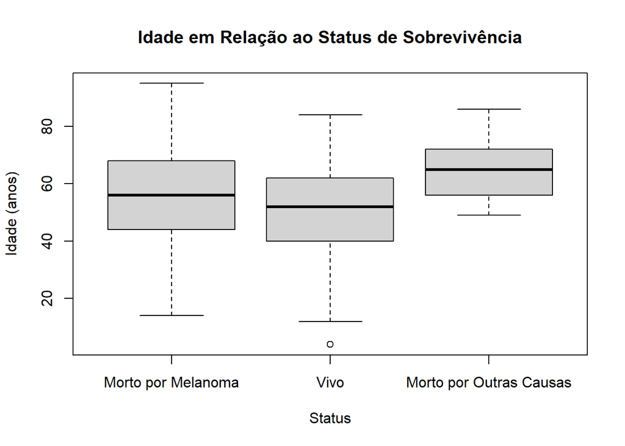

```r
# Idade x Status
boxplot(Melanoma$age ~ Melanoma$status,
        xlab = "Status",
        ylab = "Idade (anos)",
        main = "Idade em Relação ao Status de Sobrevivência",
        names = c("Morto por Melanoma", "Vivo", "Morto por Outras Causas"))
```

```r
tapply(Melanoma$age, Melanoma$status, summary)
```

```
## $`1`
##    Min. 1st Qu.  Median    Mean 3rd Qu.    Max.
##   14.00   44.00   56.00   55.09   68.00   95.00
##
## $`2`
##    Min. 1st Qu.  Median    Mean 3rd Qu.    Max.
##    4.00   40.00   52.00   50.01   61.75   84.00
##
## $`3`
##    Min. 1st Qu.  Median    Mean 3rd Qu.    Max.
##   49.00   57.00   65.00   65.29   71.75   86.00
```

No grupo que faleceu por melanoma, a idade *média* foi de **55,09** anos, enquanto no grupo que faleceu por outras causas foi de **65,3** anos e no grupo que sobreviveu foi de **50** anos. Sobre os valores *máximos*, temos o grupo de óbito pelo melanoma apresentando a maior máxima, com **95** anos, enquanto os demais grupos são **84** anos (vivo) e **86** anos para óbitos pode outras causas. Já sobre as idades *minimas*, temos **49** anos para o grupo de óbito por outras causas, **14** anos para o grupo de óbito por melanoma e **4** anos para o grupo de sobreviventes.

#### Variável Espessura:

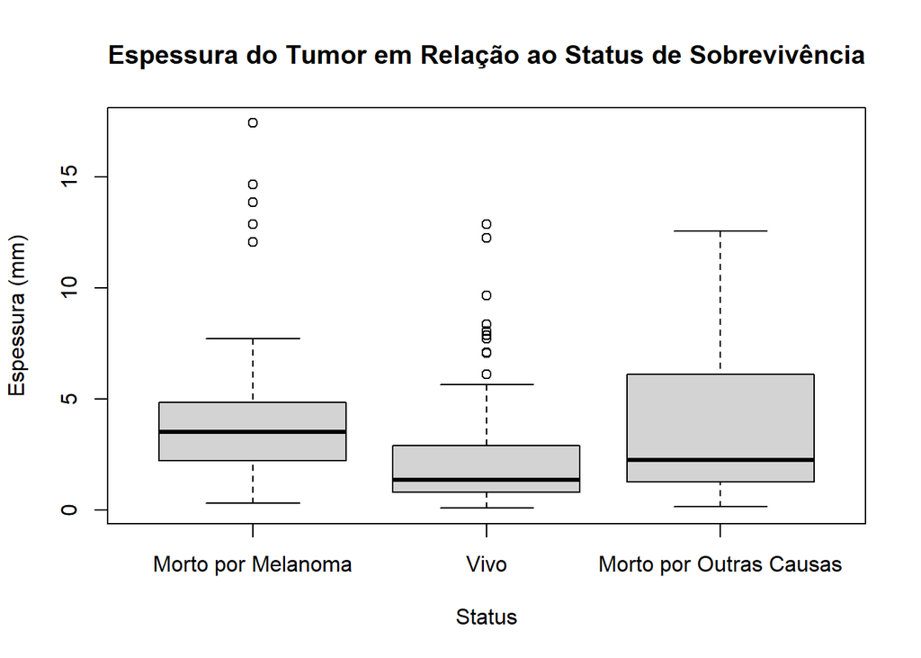

```r
# Espessura x Status
boxplot(Melanoma$thickness ~ Melanoma$status,
        xlab = "Status",
        ylab = "Espessura (mm)",
        main = "Espessura do Tumor em Relação ao Status de Sobrevivência",
        names = c("Morto por Melanoma", "Vivo", "Morto por Outras Causas"))
```

```r
tapply(Melanoma$thickness, Melanoma$status, summary)
```

```
## $`1`
##    Min. 1st Qu.  Median    Mean 3rd Qu.    Max.
##   0.320   2.240   3.540   4.311   4.840  17.420
##
## $`2`
##    Min. 1st Qu.  Median    Mean 3rd Qu.    Max.
##   0.100   0.810   1.355   2.245   2.860  12.880
##
## $`3`
##    Min. 1st Qu.  Median    Mean 3rd Qu.    Max.
##   0.160   1.290   2.260   3.718   5.800  12.560
```

No grupo que faleceu por melanoma, a espessura *média* foi de **4,31** mm, enquanto no grupo que faleceu por outras causas foi de **3,72** mm e no grupo que sobreviveu foi de **2,24** mm. Sobre os valores *máximos*, temos o grupo de óbito pelo melanoma apresentando a maior máxima, com **17,42** mm, enquanto os demais grupos são **12,88** mm (vivo) e **12,56** mm para óbitos pode outras causas. Já sobre as espessuras *minimas*, temos **0,16** mm para o grupo de óbito por outras causas, **0,32** mm para o grupo de óbito por melanoma e **0,1** mm para o grupo de sobreviventes.

### Distribuição das variáveis categóricas

#### Variável Sexo

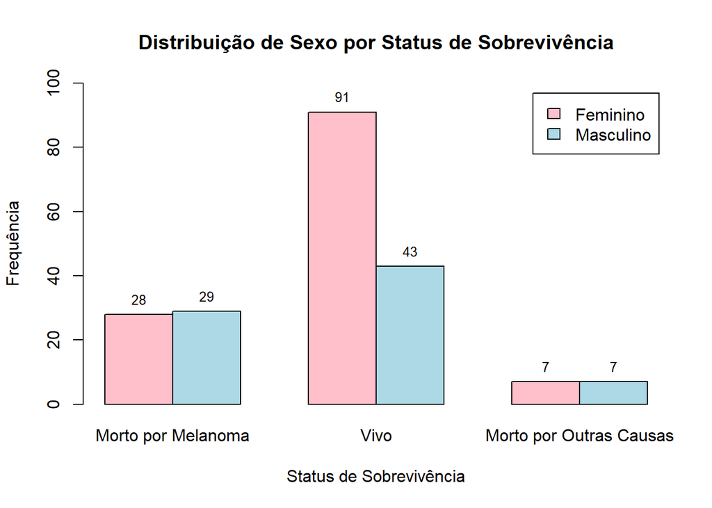

```r
table_sex <- table(Melanoma$sex, Melanoma$status)
bp <- barplot(table_sex,
              beside = TRUE,
              col = c("pink", "lightblue"),
              legend = c("Feminino", "Masculino"),
              xlab = "Status de Sobrevivência",
              ylab = "Frequência",
              main = "Distribuição de Sexo por Status de Sobrevivência",
              names.arg = c("Morto por Melanoma", "Vivo", "Morto por Outras Causas"),
              ylim = c(0, 100))
text(x = bp, y = table_sex, label = table_sex, pos = 3, cex = 0.8, col = "black")
```

### Variável Ulceração

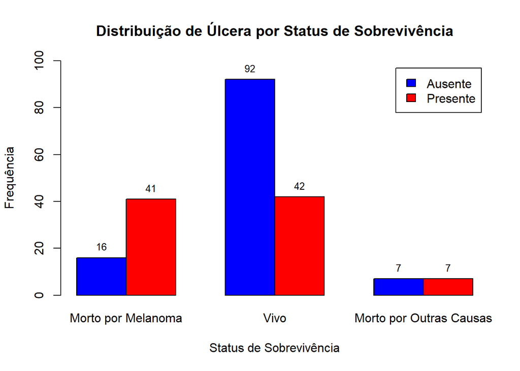

```r
table_ulcer <- table(Melanoma$ulcer, Melanoma$status)
bp <- barplot(table_ulcer,
              beside = TRUE,
              col = c("blue", "red"),
              legend.text = c("Ausente","Presente"),
              xlab = "Status de Sobrevivência",
              ylab = "Frequência",
              main = "Distribuição de Úlcera por Status de Sobrevivência",
              names.arg = c("Morto por Melanoma", "Vivo", "Morto por Outras Causas"),
              ylim = c(0, 100))
text(x = bp, y = table_ulcer, labels = table_ulcer, pos = 3, cex = 0.8, col = "black")
```

No grupo que faleceu por melanoma, a quantidade de *úlceras presentes* foi de **41** pessoas, enquanto no grupo que faleceu por outras causas foi de **7** pessoas e no grupo que sobreviveu foi de **42** pessoas. Já a quantidade de *úlceras ausentes* foi de **16** pessoas para óbito por melanoma, **7** pessoas para óbito por outras causas e **92** pessoas para sobreviventes.

## Ajuste do modelo de regressão logística

#### Ajuste do modelo de acordo com abordagem proposta por Hosmer & Lemeshow

### Avaliação das variáveis preditoras individualmente

```r
## Modelo 1: Avaliação da idade como preditor
m1 <- glm(status ~ age, data = Melanoma, family = binomial)
summary(m1)
```

```
##
## Call:
## glm(formula = status ~ age, family = binomial, data = Melanoma)
##
## Coefficients:
##              Estimate Std. Error z value Pr(>|z|)
## (Intercept)  1.671719   0.545139   3.067  0.00217 **
## age         -0.013465   0.009649  -1.395  0.16288
## ---
## Signif. codes:  0 '***' 0.001 '**' 0.01 '*' 0.05 '.' 0.1 ' ' 1
##
## (Dispersion parameter for binomial family taken to be 1)
##
##     Null deviance: 242.35  on 204  degrees of freedom
## Residual deviance: 240.36  on 203  degrees of freedom
## AIC: 244.36
##
## Number of Fisher Scoring iterations: 4
```

A modelagem 1 para avaliação da **idade** como predito mostra que a variável idade não é um bom preditor, pois o valor de **p = 0,16288**, *descartando* a influencia do preditor idade no modelo.

```r
## Modelo 2: Avaliação da espessura como preditor
m2 <- glm(status ~ thickness, data = Melanoma, family = binomial)
summary(m2)
```

```
##
## Call:
## glm(formula = status ~ thickness, family = binomial, data = Melanoma)
##
## Coefficients:
##             Estimate Std. Error z value Pr(>|z|)
## (Intercept)  1.61404    0.24268   6.651 2.91e-11 ***
## thickness   -0.20884    0.05574  -3.747 0.000179 ***
## ---
## Signif. codes:  0 '***' 0.001 '**' 0.01 '*' 0.05 '.' 0.1 ' ' 1
##
## (Dispersion parameter for binomial family taken to be 1)
##
##     Null deviance: 242.35  on 204  degrees of freedom
## Residual deviance: 226.13  on 203  degrees of freedom
## AIC: 230.13
##
## Number of Fisher Scoring iterations: 4
```

A modelagem 2 para avaliação da **espessura** como predito mostra que a variável espessura é um bom preditor, pois o valor de **p = 0.000179**, *indicando* que a espessura **é um preditor** para o modelo.

```r
## Modelo 3: Avaliação da ulceração como preditor
m3 <- glm(status ~ ulcer, data = Melanoma, family = binomial)
summary(m3)     ###   p < 0,05, a ulceração é um bom preditor
```

```
##
## Call:
## glm(formula = status ~ ulcer, family = binomial, data = Melanoma)
##
## Coefficients:
##             Estimate Std. Error z value Pr(>|z|)
## (Intercept)   1.8225     0.2694   6.764 1.34e-11 ***
## ulcer1       -1.6443     0.3426  -4.799 1.60e-06 ***
## ---
## Signif. codes:  0 '***' 0.001 '**' 0.01 '*' 0.05 '.' 0.1 ' ' 1
##
## (Dispersion parameter for binomial family taken to be 1)
##
##     Null deviance: 242.35  on 204  degrees of freedom
## Residual deviance: 216.83  on 203  degrees of freedom
## AIC: 220.83
##
## Number of Fisher Scoring iterations: 4
```

A modelagem 3 para avaliação da **ulceração** como predito mostra que a variável ulceração é um bom preditor, pois o valor de **p = 1.60e-06**, *indicando* que a ulceração **é um preditor** para o modelo.

```r
## Modelo 4: Avaliação do sexo como preditor
m4 <- glm(status ~ sex, data = Melanoma, family = binomial)
summary(m4)
```

```
##
## Call:
## glm(formula = status ~ sex, family = binomial, data = Melanoma)
##
## Coefficients:
##             Estimate Std. Error z value Pr(>|z|)
## (Intercept)   1.2528     0.2143   5.846 5.03e-09 ***
## sex1         -0.7080     0.3169  -2.235   0.0254 *
## ---
## Signif. codes:  0 '***' 0.001 '**' 0.01 '*' 0.05 '.' 0.1 ' ' 1
##
## (Dispersion parameter for binomial family taken to be 1)
##
##     Null deviance: 242.35  on 204  degrees of freedom
## Residual deviance: 237.35  on 203  degrees of freedom
## AIC: 241.35
##
## Number of Fisher Scoring iterations: 4
```

A modelagem 4 para avaliação do **sexo** como predito mostra que a variável sexo poderia ser um preditor, pois o valor de **p = 0.0254**, sendo inferior a 0,05, *contudo* ao ser análisada a distribuição por sexo por status de sobrevivência, vemos que no grupo *“morto por Melanoma”* não existe diferença entre os sexo. O baixo valor de p nesta análise provavelmente é decorrente da diferença entre mulheres e homens no grupo de pessoas que sobreviveram. Então, dessa forma, considerando as análises anteriores, a variável sexo é **descartada** na questão de influencia do preditor sexo no modelo.

### Ajuste do modelo multivariável considerando todas as variáveis que tiveram p < 0,05 no passo anterior

```r
model <- glm(status == 1 ~ thickness + ulcer, data = Melanoma, family = binomial)
summary(model)
```

```
##
## Call:
## glm(formula = status == 1 ~ thickness + ulcer, family = binomial,
##     data = Melanoma)
##
## Coefficients:
##             Estimate Std. Error z value Pr(>|z|)
## (Intercept) -2.08243    0.30135  -6.910 4.83e-12 ***
## thickness    0.12751    0.05785   2.204 0.027524 *
## ulcer1       1.35273    0.36593   3.697 0.000218 ***
## ---
## Signif. codes:  0 '***' 0.001 '**' 0.01 '*' 0.05 '.' 0.1 ' ' 1
##
## (Dispersion parameter for binomial family taken to be 1)
##
##     Null deviance: 242.35  on 204  degrees of freedom
## Residual deviance: 211.85  on 202  degrees of freedom
## AIC: 217.85
##
## Number of Fisher Scoring iterations: 4
```

O modelo final ajustado considerando as variáveis **espessura** e **ulceração** como preditores, mostra que a espessura e a ulceração são preditores significativos para o modelo, com valores de **p = 0.027524** e **p = 0.000218** respectivamente.

O modelo mostrou que tanto a **espessura do tumor** (thickness) quanto a presença de **úlcera** (ulcer) **são fatores significativos**.

A **espessura do tumor** está **positivamente** associada à probabilidade de mortalidade por melanoma, enquanto a presença de **úlcera aumenta** ainda mais essa probabilidade.

O **intercepto negativo** indica que, para pacientes com **baixa espessura** de tumor e **sem úlcera**, as chances de **sobrevivência** são consideravelmente **mais altas**.

### Estatísticas de diagnóstico do modelo

Medida de ajuste global: teste de Hosmer e Lemeshow  
**H0:** o modelo está bem ajustado.

```r
glmtoolbox::hltest(model)
```

```
##
##    The Hosmer-Lemeshow goodness-of-fit test
##
##  Group Size Observed  Expected
##      1   22        1  2.540272
##      2   19        3  2.285205
##      3   26        1  3.275069
##      4   23        5  3.094584
##      5   21        5  3.431573
##      6   20        4  7.027894
##      7   18        8  7.101101
##      8   22       12  9.530611
##      9   21       12 10.355445
##     10   13        6  8.358246
##
##          Statistic =  11.03746
## degrees of freedom =  8
##            p-value =  0.19959
```

O teste de Hosmer e Lemeshow mostra que o modelo está **bem ajustado**, com valor de **p = 0.19959** (p > 0,05 *aceita* a hipótese nula).

### Avaliação das medidas de influência

Avaliação das medidas da distância de cook

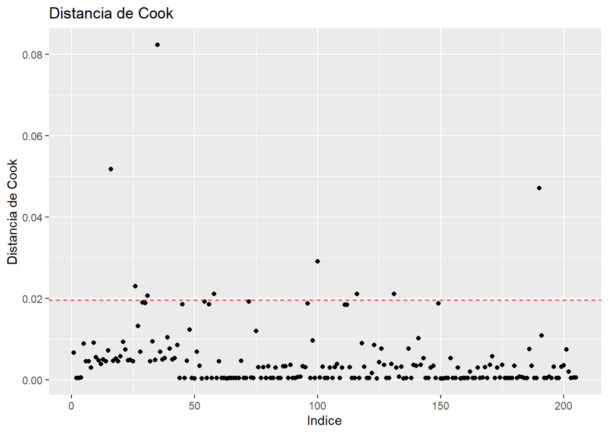

```r
dist_cook <- data.frame(id = 1:nrow(Melanoma), dist_cook = stats::cooks.distance(model))
ggplot(dist_cook, aes(x = id, y = dist_cook)) +
  geom_point() +
  geom_hline(yintercept = 4/nrow(Melanoma), color = "red", linetype = "dashed") +
  labs(title = "Distancia de Cook",
       x = "Indice",
       y = "Distancia de Cook")
```

### Avaliação dos resíduos

Avaliação dos **resíduos de Pearson** e **resíduos de deviance**.

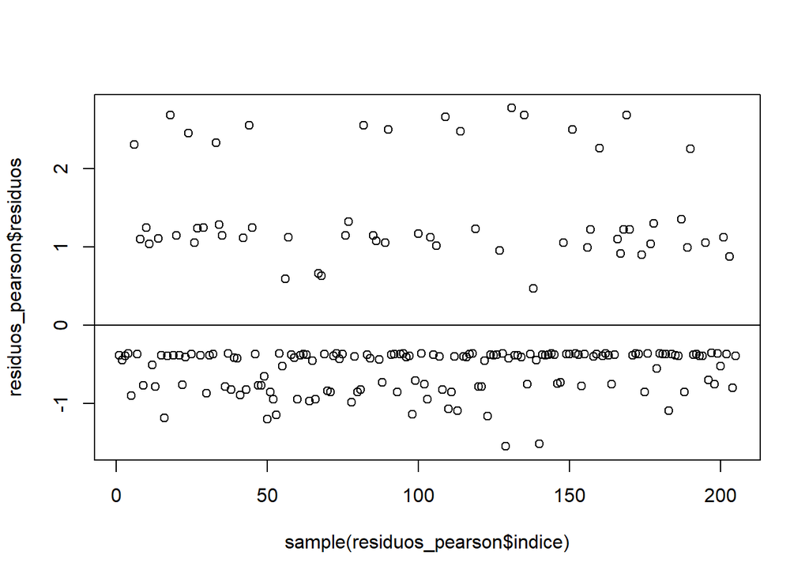

```r
residuos_pearson <- data.frame(indice = 1:nrow(Melanoma),
                               residuos = residuals(model, type = "pearson"))
plot(x = sample(residuos_pearson$indice), y = residuos_pearson$residuos)
abline(0, 0)
```

Os **resíduos de Pearson** estão distribuídos de forma aleatória, **sem padrões aparentes**, o que indica que o modelo está **bem ajustado**.

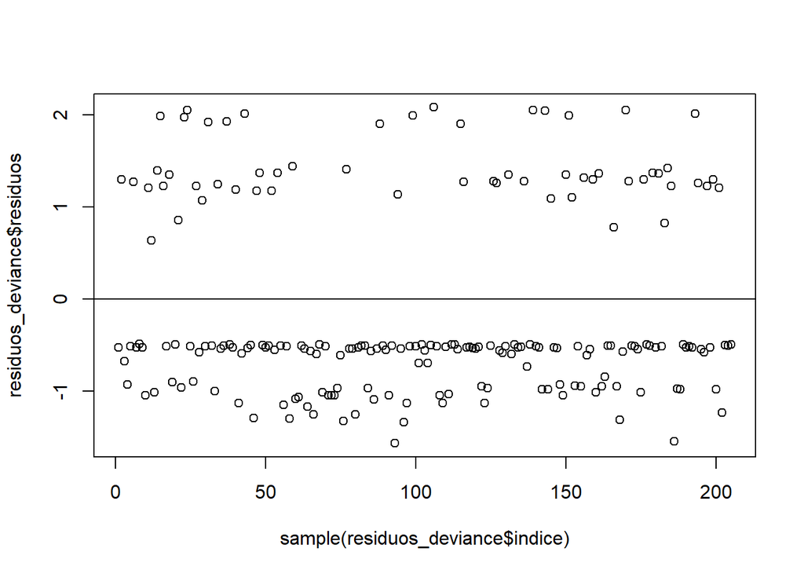

```r
### 4. Avaliação dos resíduos da deviance
residuos_deviance <- data.frame(indice = 1:nrow(Melanoma),
                                residuos = residuals(model, type = "deviance"))
plot(x = sample(residuos_deviance$indice), y = residuos_deviance$residuos)
abline(0, 0)
```

Os **resíduos de deviance** estão distribuídos de forma aleatória, **sem padrões aparentes**, o que indica que o modelo está **bem ajustado**.

### Avaliação da multicolinearidade

```r
vif(model)
```

```
## thickness     ulcer
##   1.11191   1.11191
```

Com o valor da análise de multicolinearidade baixo (1.111 para ambas as variáveis), podemos considerar que o modelo está **bem ajustado**, uma vez que as variáveis **não estão correlacionadas** pelo baixo valor do teste.

### Avaliação da significância dos coeficientes

```r
exp(coef(model))
```

```
## (Intercept)   thickness      ulcer1
##   0.1246276   1.1359992   3.8679665
```

Os coeficientes do modelo ajustado são **significativos**, levando as conclusões:  
- A cada **aumento de 1 unidade na espessura do tumor**, espera-se um aumento de aproximadamente **13.6%** nas chances de morte por melanoma  
- Pacientes com **úlcera** têm aproximadamente **3.87 vezes** maior chance de morte por melanoma em comparação com pacientes sem úlcera

### Intervalo de confiança dos coeficientes

```r
exp(confint(model))
```

```
##                  2.5 %    97.5 %
## (Intercept) 0.06639189 0.2178739
## thickness   1.01567446 1.2777107
## ulcer1      1.90931974 8.0736572
```

Os intervalos de confiança dos coeficientes são **significativos**, com valores variando entre **1.015** e **1.27** para a **espessura** do tumor e entre **1.90** e **8.07** para a presença de **úlcera**.

### Resumo final:

Vemos que o modelo criado é **bem ajustado**, com as variáveis **espessura** e **úlcera** sendo **preditoras significativas** para a probabilidade de óbito por melanoma. A presença de **ulcera** aumenta a probabilidade em **3,87 vezes** da pessoa vir a óbito pelo tumor, sendo um fator de risco muito grande. Já a **espessura** do tumor, a cada **aumento de 1 unidade**, espera-se um aumento de aproximadamente **13.6%** nas chances de morte por melanoma. Também sendo um fator de risco relevante para a análise.  
O modelo é **bem ajustado**, com **baixa multicolinearidade** e **resíduos bem distribuídos**, indicando que o modelo é **confiável** para prever a probabilidade de óbito por melanoma.

**—– fim do relatório —–**